# nycflights13

Pauline Marie PERRIN

2022-05-06

# Introduction

Ce document a pour but de rechercher et d’analyser quelques informations issues de la base de données nycflights13. Celle-ci concerne les vols d’un certain nombre de compagnies aériennes en provenance et à destination de plusieurs aéroports localisés à New York City.

# Import du jeu de données

```r
library(nycflights13)
flights
```

```
## # A tibble: 336,776 × 19
##     year month   day dep_time sched_dep_time dep_delay arr_time sched_arr_time
##    <int> <int> <int>    <int>          <int>     <dbl>    <int>          <int>
##  1  2013     1     1      517            515         2      830            819
##  2  2013     1     1      533            529         4      850            830
##  3  2013     1     1      542            540         2      923            850
##  4  2013     1     1      544            545        -1     1004           1022
##  5  2013     1     1      554            600        -6      812            837
##  6  2013     1     1      554            558        -4      740            728
##  7  2013     1     1      555            600        -5      913            854
##  8  2013     1     1      557            600        -3      709            723
##  9  2013     1     1      557            600        -3      838            846
## 10  2013     1     1      558            600        -2      753            745
## # … with 336,766 more rows, and 11 more variables: arr_delay <dbl>,
## #   carrier <chr>, flight <int>, tailnum <chr>, origin <chr>, dest <chr>,
## #   air_time <dbl>, distance <dbl>, hour <dbl>, minute <dbl>, time_hour <dttm>
```

```r
library(dplyr)
```

# Recherche d’informations

Dans un premier temps, on identification des variables du jeu de données nycflights13

```r
head(flights)
```

```
## # A tibble: 6 × 19
##    year month   day dep_time sched_dep_time dep_delay arr_time sched_arr_time
##   <int> <int> <int>    <int>          <int>     <dbl>    <int>          <int>
## 1  2013     1     1      517            515         2      830            819
## 2  2013     1     1      533            529         4      850            830
## 3  2013     1     1      542            540         2      923            850
## 4  2013     1     1      544            545        -1     1004           1022
## 5  2013     1     1      554            600        -6      812            837
## 6  2013     1     1      554            558        -4      740            728
## # … with 11 more variables: arr_delay <dbl>, carrier <chr>, flight <int>,
## #   tailnum <chr>, origin <chr>, dest <chr>, air_time <dbl>, distance <dbl>,
## #   hour <dbl>, minute <dbl>, time_hour <dttm>
```

```r
names(flights)
```

```
##  [1] "year"           "month"          "day"            "dep_time"
##  [5] "sched_dep_time" "dep_delay"      "arr_time"       "sched_arr_time"
##  [9] "arr_delay"      "carrier"        "flight"         "tailnum"
## [13] "origin"         "dest"           "air_time"       "distance"
## [17] "hour"           "minute"         "time_hour"
```

Ensuite, on décrit le contexte statistique

```r
dim(flights)
```

```
## [1] 336776     19
```

```r
ncol(flights)
```

```
## [1] 19
```

```r
nrow(flights)
```

```
## [1] 336776
```

Nous pouvons ensuite mettre en évidence un certain nombre d’informations :

## 1. Sélection des vols à destination de Houston (IAH or HOU)

```r
flights %>%
  filter(dest=="IAH" | dest =="HOU")
```

```
## # A tibble: 9,313 × 19
##     year month   day dep_time sched_dep_time dep_delay arr_time sched_arr_time
##    <int> <int> <int>    <int>          <int>     <dbl>    <int>          <int>
##  1  2013     1     1      517            515         2      830            819
##  2  2013     1     1      533            529         4      850            830
##  3  2013     1     1      623            627        -4      933            932
##  4  2013     1     1      728            732        -4     1041           1038
##  5  2013     1     1      739            739         0     1104           1038
##  6  2013     1     1      908            908         0     1228           1219
##  7  2013     1     1     1028           1026         2     1350           1339
##  8  2013     1     1     1044           1045        -1     1352           1351
##  9  2013     1     1     1114            900       134     1447           1222
## 10  2013     1     1     1205           1200         5     1503           1505
## # … with 9,303 more rows, and 11 more variables: arr_delay <dbl>,
## #   carrier <chr>, flight <int>, tailnum <chr>, origin <chr>, dest <chr>,
## #   air_time <dbl>, distance <dbl>, hour <dbl>, minute <dbl>, time_hour <dttm>
```

## 2. Sélection des vols arrivés avec un retard de deux heures ou plus

```r
flights %>%
  filter(flights$arr_delay >= 120)
```

```
## # A tibble: 10,200 × 19
##     year month   day dep_time sched_dep_time dep_delay arr_time sched_arr_time
##    <int> <int> <int>    <int>          <int>     <dbl>    <int>          <int>
##  1  2013     1     1      811            630       101     1047            830
##  2  2013     1     1      848           1835       853     1001           1950
##  3  2013     1     1      957            733       144     1056            853
##  4  2013     1     1     1114            900       134     1447           1222
##  5  2013     1     1     1505           1310       115     1638           1431
##  6  2013     1     1     1525           1340       105     1831           1626
##  7  2013     1     1     1549           1445        64     1912           1656
##  8  2013     1     1     1558           1359       119     1718           1515
##  9  2013     1     1     1732           1630        62     2028           1825
## 10  2013     1     1     1803           1620       103     2008           1750
## # … with 10,190 more rows, and 11 more variables: arr_delay <dbl>,
## #   carrier <chr>, flight <int>, tailnum <chr>, origin <chr>, dest <chr>,
## #   air_time <dbl>, distance <dbl>, hour <dbl>, minute <dbl>, time_hour <dttm>
```

## 3. Sélection des vols réalisés par les compagnies United, American, ou Delta

```r
flights %>%
  filter(flights$carrier %in% c("AA","UA","DL"))
```

```
## # A tibble: 139,504 × 19
##     year month   day dep_time sched_dep_time dep_delay arr_time sched_arr_time
##    <int> <int> <int>    <int>          <int>     <dbl>    <int>          <int>
##  1  2013     1     1      517            515         2      830            819
##  2  2013     1     1      533            529         4      850            830
##  3  2013     1     1      542            540         2      923            850
##  4  2013     1     1      554            600        -6      812            837
##  5  2013     1     1      554            558        -4      740            728
##  6  2013     1     1      558            600        -2      753            745
##  7  2013     1     1      558            600        -2      924            917
##  8  2013     1     1      558            600        -2      923            937
##  9  2013     1     1      559            600        -1      941            910
## 10  2013     1     1      559            600        -1      854            902
## # … with 139,494 more rows, and 11 more variables: arr_delay <dbl>,
## #   carrier <chr>, flight <int>, tailnum <chr>, origin <chr>, dest <chr>,
## #   air_time <dbl>, distance <dbl>, hour <dbl>, minute <dbl>, time_hour <dttm>
```

## 4. Sélection des vols réalisés en été (Juillet, Août et Septembre)

```r
flights %>%
  filter(flights$month %in% c(7,8,9))
```

```
## # A tibble: 86,326 × 19
##     year month   day dep_time sched_dep_time dep_delay arr_time sched_arr_time
##    <int> <int> <int>    <int>          <int>     <dbl>    <int>          <int>
##  1  2013     7     1        1           2029       212      236           2359
##  2  2013     7     1        2           2359         3      344            344
##  3  2013     7     1       29           2245       104      151              1
##  4  2013     7     1       43           2130       193      322             14
##  5  2013     7     1       44           2150       174      300            100
##  6  2013     7     1       46           2051       235      304           2358
##  7  2013     7     1       48           2001       287      308           2305
##  8  2013     7     1       58           2155       183      335             43
##  9  2013     7     1      100           2146       194      327             30
## 10  2013     7     1      100           2245       135      337            135
## # … with 86,316 more rows, and 11 more variables: arr_delay <dbl>,
## #   carrier <chr>, flight <int>, tailnum <chr>, origin <chr>, dest <chr>,
## #   air_time <dbl>, distance <dbl>, hour <dbl>, minute <dbl>, time_hour <dttm>
```

## 5. Sélection des vols arrivés avec plus de deux heures de retard mais qui sont partis à l’heure

```r
flights %>%
  filter((flights$arr_delay > 120) & (flights$dep_delay <= 0))
```

```
## # A tibble: 29 × 19
##     year month   day dep_time sched_dep_time dep_delay arr_time sched_arr_time
##    <int> <int> <int>    <int>          <int>     <dbl>    <int>          <int>
##  1  2013     1    27     1419           1420        -1     1754           1550
##  2  2013    10     7     1350           1350         0     1736           1526
##  3  2013    10     7     1357           1359        -2     1858           1654
##  4  2013    10    16      657            700        -3     1258           1056
##  5  2013    11     1      658            700        -2     1329           1015
##  6  2013     3    18     1844           1847        -3       39           2219
##  7  2013     4    17     1635           1640        -5     2049           1845
##  8  2013     4    18      558            600        -2     1149            850
##  9  2013     4    18      655            700        -5     1213            950
## 10  2013     5    22     1827           1830        -3     2217           2010
## # … with 19 more rows, and 11 more variables: arr_delay <dbl>, carrier <chr>,
## #   flight <int>, tailnum <chr>, origin <chr>, dest <chr>, air_time <dbl>,
## #   distance <dbl>, hour <dbl>, minute <dbl>, time_hour <dttm>
```

## 6. Sélection des vols partis entre minuit et 6 heures du matin inclus

```r
flights %>%
  filter(flights$hour <= 6 | flights$hour == 24)
```

```
## # A tibble: 27,905 × 19
##     year month   day dep_time sched_dep_time dep_delay arr_time sched_arr_time
##    <int> <int> <int>    <int>          <int>     <dbl>    <int>          <int>
##  1  2013     1     1      517            515         2      830            819
##  2  2013     1     1      533            529         4      850            830
##  3  2013     1     1      542            540         2      923            850
##  4  2013     1     1      544            545        -1     1004           1022
##  5  2013     1     1      554            600        -6      812            837
##  6  2013     1     1      554            558        -4      740            728
##  7  2013     1     1      555            600        -5      913            854
##  8  2013     1     1      557            600        -3      709            723
##  9  2013     1     1      557            600        -3      838            846
## 10  2013     1     1      558            600        -2      753            745
## # … with 27,895 more rows, and 11 more variables: arr_delay <dbl>,
## #   carrier <chr>, flight <int>, tailnum <chr>, origin <chr>, dest <chr>,
## #   air_time <dbl>, distance <dbl>, hour <dbl>, minute <dbl>, time_hour <dttm>
```

## 7. Sélection des vols American ayant un retard de 2h ou plus au décollage

```r
flights %>%
  filter(carrier=="AA") %>%
  filter(dep_delay>120)
```

```
## # A tibble: 720 × 19
##     year month   day dep_time sched_dep_time dep_delay arr_time sched_arr_time
##    <int> <int> <int>    <int>          <int>     <dbl>    <int>          <int>
##  1  2013     1     1     1856           1645       131     2212           2005
##  2  2013     1     1     2205           1720       285       46           2040
##  3  2013     1     2     1607           1030       337     2003           1355
##  4  2013     1     2     1751           1450       181     2041           1755
##  5  2013     1     3      854            630       144     1057            810
##  6  2013     1     3      909            700       129     1103            850
##  7  2013     1     3     1758           1550       128     2240           2050
##  8  2013     1     3     1821           1530       171     2131           1910
##  9  2013     1     4     1305           1030       155     1452           1210
## 10  2013     1     4     1917           1700       137     2135           1950
## # … with 710 more rows, and 11 more variables: arr_delay <dbl>, carrier <chr>,
## #   flight <int>, tailnum <chr>, origin <chr>, dest <chr>, air_time <dbl>,
## #   distance <dbl>, hour <dbl>, minute <dbl>, time_hour <dttm>
```

## 8. Sélection des variables textuelles dans le tableau

```r
flights %>%
  select(where(is.character))
```

```
## # A tibble: 336,776 × 4
##    carrier tailnum origin dest
##    <chr>   <chr>   <chr>  <chr>
##  1 UA      N14228  EWR    IAH
##  2 UA      N24211  LGA    IAH
##  3 AA      N619AA  JFK    MIA
##  4 B6      N804JB  JFK    BQN
##  5 DL      N668DN  LGA    ATL
##  6 UA      N39463  EWR    ORD
##  7 B6      N516JB  EWR    FLL
##  8 EV      N829AS  LGA    IAD
##  9 B6      N593JB  JFK    MCO
## 10 AA      N3ALAA  LGA    ORD
## # … with 336,766 more rows
```

## 9. Création d’une nouvelle colonne avec la durée de vol en heures à partir d’une variable existante

On a pu remarquer que les durées de vol étaient données en minutes. Pour mettre en forme nos données, il peut être intéressant de créer une nouvelle colonne à partir d’une variable existante avec ces durées de vol en heures :

```r
flights %>%
  mutate(duree = air_time/60) %>%
  select(flight, duree, air_time) %>%
  arrange(air_time)
```

```
## # A tibble: 336,776 × 3
##    flight duree air_time
##     <int> <dbl>    <dbl>
##  1   4368 0.333       20
##  2   4631 0.333       20
##  3   4276 0.35        21
##  4   4619 0.35        21
##  5   4368 0.35        21
##  6   4619 0.35        21
##  7   2132 0.35        21
##  8   3650 0.35        21
##  9   4118 0.35        21
## 10   4276 0.35        21
## # … with 336,766 more rows
```

# Création de graphiques

Pour créer nos graphiques, nous avons recours au package ggplot. Il s’agit d’une extension de tidyverse qui permet de concevoir des graphiques plus attractifs et plus complexes.

```r
library(tidyverse)
```

## 1. Graphique des proportions de vols réalisés par chacune des compagnies aériennes étudiées

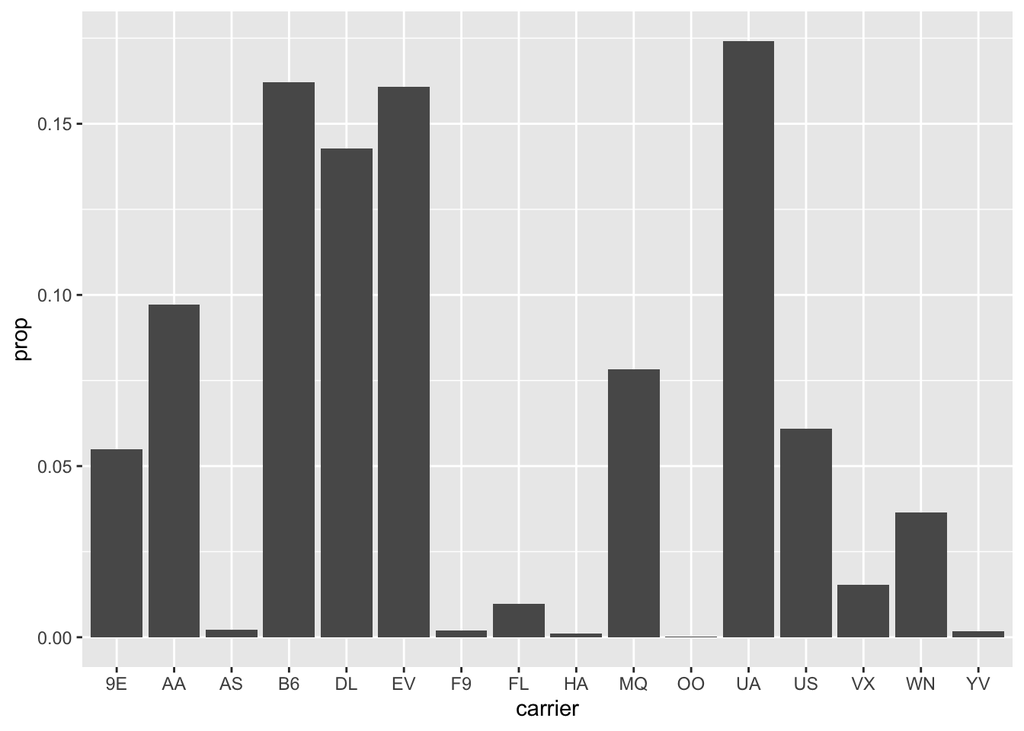

```r
ggplot(data=flights) +
  geom_bar(mapping = aes(x = carrier, y = stat(prop), group = 1))
```

## 2. Répartition des compagnies aériennes en fonction des destinations

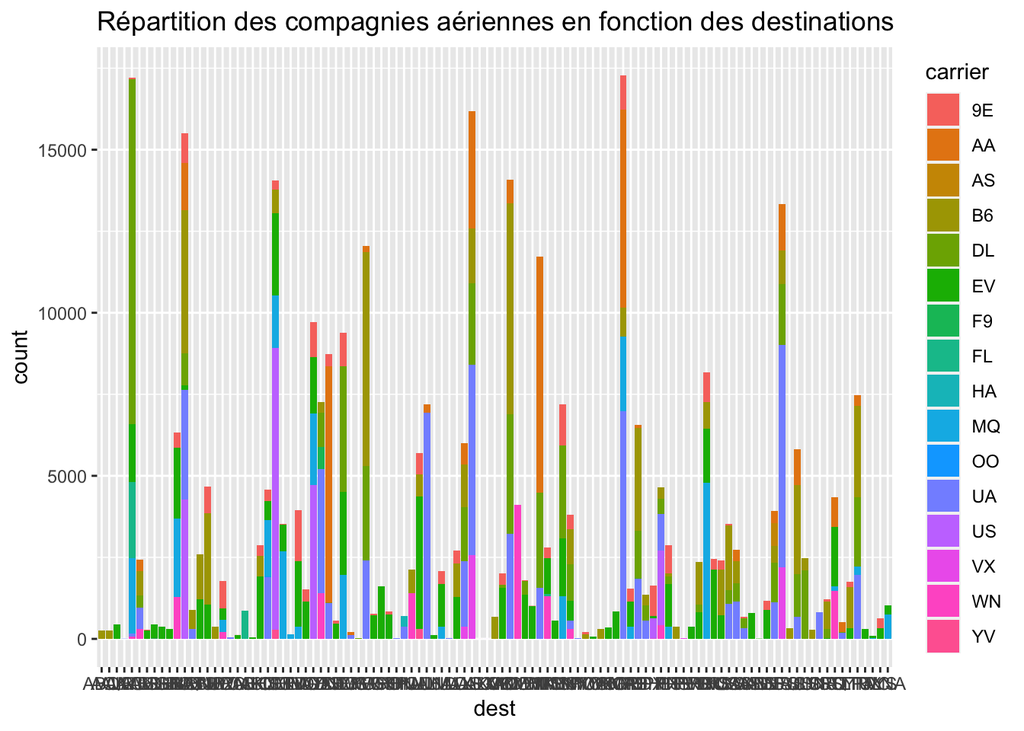

```r
ggplot(data=flights) +
  geom_bar(mapping = aes (x = dest, fill = carrier)) +
  ggtitle("Répartition des compagnies aériennes en fonction des destinations")
```

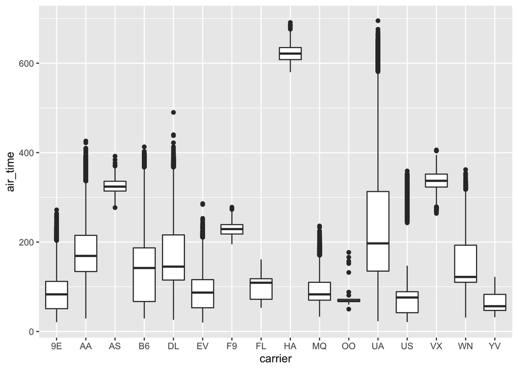

```r
flights%>%
  select(carrier, air_time) %>%
  arrange(carrier) %>%
  ggplot() +
  geom_boxplot(aes(x=carrier, y=air_time))
```